# 第8回 総合演習：教師ありを一周する

理解・前処理・交差検証・テスト・係数・1本のスクリプト

# 導入

## 道具は、そろった

- データを見る、前処理、モデル、交差検証、テスト、係数、しきい値
- 第1回から第7回で、教師あり学習の道具がひととおり

## 今日は、一周する

- 新しいデータで、最初から最後まで
- 新しい書き方は、ほとんど出てこない

## あなたは、南極の調査担当者

- 測定値から、ペンギンの種（3種）を見分けたい
- どの測定が役立つかを、調査チームに報告したい

## 今日の問い

測定値から3種を見分けられるか？ どの測定が、見分けに役立つか？

## 今日のコードの書き方

- 今日のコードを、4つの関数に分ける
- 関数の定義と、それを呼ぶ手順を分けた、1本のスクリプトにまとめる
- スクリプトは、上から順に実行すれば最後まで動く、ひとまとまりのコード

## この問いに、どう近づくか

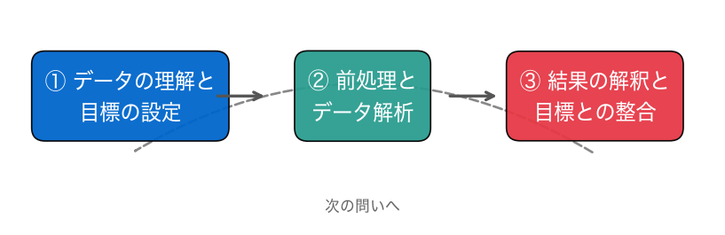

総合演習なので、①から③まで全部回ります。

# 0. 設定

## やってみよう：0節

- 第8回のノートを開き、ドライブにコピーする
- 0節の設定のセルを実行し、「セットアップ完了」を確かめる

動画の人は、ここで一時停止。

# 1. データを理解する

## 3種を見分けたい。どう違う？

- 測定値から、3種を見分けたい
- まず、種ごとの違いと、欠けた値を見る

## お手本：種ごとに比べる

```python
# データはこのリポジトリから読み込む
DATA_DIR = ('https://raw.githubusercontent.com/k0heiun0/'
            'applied_exercise_preview/main/shared/data')
df = pd.read_csv(f'{DATA_DIR}/penguins.csv')
print(df['species'].value_counts())
num = ['bill_length_mm', 'bill_depth_mm',
       'flipper_length_mm', 'body_mass_g']
print(df.groupby('species')[num].mean().round(1))
```

- 役割：種ごとの羽数と、4本の測定値の平均を比べる

## 変えてみる：種と島のクロス集計

```python
print(pd.crosstab(df['species'], df['island']))
```

- `pd.crosstab`：2つの区分の組み合わせごとに数を数えた表

## TODO①：欠けた値を数える

```python
# TODO: 列ごとの欠けた値の数と、その合計を表示する
# ヒント: df.isna().sum() で列ごと、さらに .sum() で合計
...
```

## やってみよう：1節とTODO①

- 1節のお手本と「変えてみる」のセルを実行する
- TODO①：欠けた値を数える

動画の人は、ここで一時停止。

## 答え合わせ：3種の羽数

```
species
Adelie       152
Gentoo       124
Chinstrap     68
```

- 344羽。Adelieが一番多く、Chinstrapは68羽と少ない

## 答え合わせ：種ごとの平均

```
species            Adelie  Chinstrap  Gentoo
bill_length_mm       38.8       48.8    47.5
bill_depth_mm        18.3       18.4    15.0
flipper_length_mm   190.0      195.8   217.2
body_mass_g        3700.7     3733.1  5076.0
```

- 縦と横を入れかえて表示（列が種）

## Adelieは、くちばしが短い

- Adelieのくちばしの長さは38.8 mm
- ほかの2種は、47〜49 mm

## Gentooは、浅くて大きい

- Gentooのくちばしの深さは15.0 mm。ほかの2種は18 mm台
- 翼が長く（217 mm）、体が重い（5076 g）

## Chinstrapは、Adelieに似ている

- くちばしの長さだけが違う（48.8 mm）
- 深さ・翼・体重は、Adelieとほぼ同じ

## 答え合わせ：種と島

```
island     Biscoe  Dream  Torgersen
species
Adelie         44     56         52
Chinstrap       0     68          0
Gentoo        124      0          0
```

## 島だけで、かなり決まる

- ChinstrapはDream島にしかいない
- GentooはBiscoe島にしかいない
- 島は、種を見分ける強い手がかりになりそう

## 答え合わせ：TODO①

```
species               0
island                0
bill_length_mm        2
bill_depth_mm         2
flipper_length_mm     2
body_mass_g           2
sex                  11
合計: 19
```

- 測定値は各2つ、性別は11羽が欠けている

## 区分の列にも、欠けがある

- 性別にも欠けがあるので、区分の列にも補う手順が要る

# 2. 前処理を設計する

## 見たことを、設計に移す

- 測定値：欠けがある → 中央値で補う。単位がばらばら → 標準化
- 島と性別：欠けがある → 最頻値で補う。区分 → ワンホット

## おさらい：Pipeline

```python
Pipeline([('名前1', 部品1), ('名前2', 部品2)])
```

- 部品を順に並べて、1本の部品にまとめる（第7回）

## お手本：分けて、前処理を組む

```python
cat = ['island', 'sex']
X, y = df[num + cat], df['species']
X_tr, X_te, y_tr, y_te = train_test_split(X, y, test_size=0.2,
                                          random_state=42, stratify=y)
num_steps = Pipeline([('imp', SimpleImputer(strategy='median')),
                      ('sc', StandardScaler())])
cat_steps = Pipeline([
    ('imp', SimpleImputer(strategy='most_frequent')),
    ('oh', OneHotEncoder(handle_unknown='ignore'))])
pre = ColumnTransformer([('num', num_steps, num),
                         ('cat', cat_steps, cat)])
print(len(y_tr), len(y_te))
```

## TODO②：前処理のあとの列

```python
# TODO: pre を訓練で fit し、前処理のあとの列の名前を表示する
# ヒント: names = pre.fit(X_tr).get_feature_names_out()
#         print(names, len(names))
...
```

## やってみよう：2節とTODO②

- 2節のお手本のセルを実行する
- TODO②：前処理のあとの列は、何本になったか？

動画の人は、ここで一時停止。

## 答え合わせ：275羽と69羽

```
275 69
```

- `stratify=y`で、3種の割合をそろえて分けた

## 答え合わせ：TODO②

```
num__bill_length_mm
num__bill_depth_mm
num__flipper_length_mm
num__body_mass_g
cat__island_Biscoe
cat__island_Dream
cat__island_Torgersen
cat__sex_Female
cat__sex_Male
```

## 区分の2本が、5本に分かれた

- 測定値の4本
- 島の3本と、性別の2本。合わせて9本

# 3. パイプラインと交差検証

## 前処理は組めた。では、実力は？

- 前処理`pre`で、列は9本になった
- モデルとつなぎ、テストを見ずに訓練の中で測る

## お手本：交差検証で測る

```python
pipe = Pipeline([('pre', pre),
                 ('model', LogisticRegression(max_iter=5000))])
cv = cross_val_score(pipe, X_tr, y_tr, cv=5)
print(cv.round(3), round(cv.mean(), 3))
```

- 役割：前処理とモデルを1本にし、訓練の中で5分割の交差検証

## 3種でも、同じ使い方

- ロジスティック回帰は、種ごとに「その種である確率」を出す
- 一番高い種を、答えにする

## 変えてみる：Cを選ぶ

```python
grid = {'model__C': [0.01, 0.1, 1, 10, 100]}
gs = GridSearchCV(pipe, grid, cv=5).fit(X_tr, y_tr)
print(gs.best_params_, round(gs.best_score_, 3))
```

- 第7回と同じ。候補は辞書で渡す

## TODO③：区分の列は役立つか

```python
# TODO: 数の列だけのパイプラインで、交差検証の正解率の平均を出す
# ヒント: pre_n = ColumnTransformer([('num', num_steps, num)])
#         pipe_n = Pipeline([('pre', pre_n), ('model', …)])
#         （model はお手本と同じ）
...
```

## やってみよう：3節とTODO③

- 3節のお手本と「変えてみる」のセルを実行する
- TODO③：区分の列を外すと、正解率はどうなるか？

動画の人は、ここで一時停止。

## 答え合わせ：平均0.993

```
[1.    0.982 1.    0.982 1.   ] 0.993
```

- テストを見る前に、訓練の中だけで、とても高い実力が見えた

## 答え合わせ：Cは10

```
{'model__C': 10} 0.996
```

## 答え合わせ：TODO③

```
[0.982 0.945 1.    0.964 0.982] 0.975
```

- 測定値だけでは、平均0.975

## 区分の列は、役に立っていた

- 区分の列（島・性別）を入れると0.993、外すと0.975
- ただし両方外したので、どちらが役立ったかは分けられない

## 役立ったのは、主に島だろう

- 1節のクロス集計：ChinstrapはDream島だけ、GentooはBiscoe島だけ
- だから、主に島が役立ったのだろう

# 4. テストと混同行列

## Cを選んで0.996。テストでは？

- 交差検証で、C＝10のパイプライン`gs`を選んだ
- テストの正解率と、取り違えた種を見る

## お手本：テストで一度だけ

```python
labels = ['Adelie', 'Chinstrap', 'Gentoo']
print(round(gs.score(X_te, y_te), 3))
print(confusion_matrix(y_te, gs.predict(X_te), labels=labels))
```

- 役割：選んだパイプラインで、テストの正解率と、3種の混同行列を出す

## テストは、一度だけ

- テストは、最後まで取っておく本番（第2回）
- 何度も見てモデルを直すと、テストに合わせこむ
- だから、使うのは最後に一度だけ

## やってみよう：4節

- 4節のお手本のセルを実行する
- 外したのは、何羽？ どの種を、どの種と取り違えた？

動画の人は、ここで一時停止。

## 答え合わせ：0.986

```
0.986
```

- 69羽のうち、68羽を当てた

## 3種の混同行列

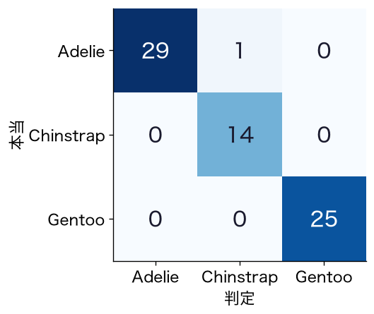

- 行が本当の種、列が判定

## 外した1羽は

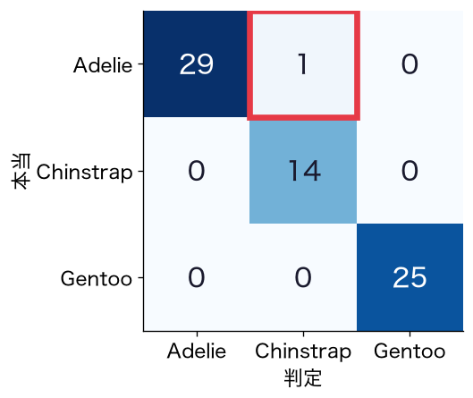

- 本当はAdelieなのに、Chinstrapと判定した1羽

## Gentooは、すべて正解

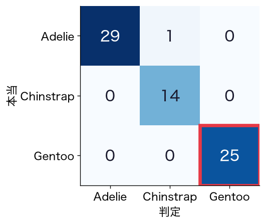

- Gentooの25羽は、1羽も外さなかった

# 5. どの測定が役立ったか

## 3種は見分けられた。どの測定で？

- テストでは、69羽のうち68羽を当てた
- 残る問いは、どの測定が見分けに役立つか

## 種ごとに、1組の係数

- 3種の分類では、種ごとに1組の係数を持つ
- Adelieの係数は「Adelieらしさ」を決める

## 測定値の4本は、比べられる

- 測定値の4本は、標準化されている
- その4本どうしなら、係数の大きさ（絶対値）で比べられる（第4回）

## 0/1の列は、単位が違う

- 島・性別のワンホットの列は、0/1のまま（標準化していない）
- 測定値の係数と、大きさをそのまま比べられない

## お手本：Adelieらしさを決める列

```python
best = gs.best_estimator_
names = best.named_steps['pre'].get_feature_names_out()
coef = best.named_steps['model'].coef_[0]       # Adelie らしさ
top = np.argsort(np.abs(coef))[::-1][:4]
for j in top:
    print(f'{names[j]:24s} {coef[j]:+.2f}')
```

## 部品を、名前で取り出す

```python
best = gs.best_estimator_
names = best.named_steps['pre'].get_feature_names_out()
```

- `named_steps`：パイプラインの部品を名前で取り出す辞書
- `coef_[0]`は1行目、つまり1番目の種（Adelie）の係数

## 大きい順に並べる

```python
top = np.argsort(np.abs(coef))[::-1][:4]
```

- `np.argsort`：小さい順の並び順を返す
- `[::-1]`で逆にして大きい順、`[:4]`で先頭4つ

## TODO④：Gentooらしさ

```python
# TODO: Gentoo の係数を、絶対値の大きい順に4本表示する
# ヒント: お手本の coef_[0] を coef_[2] に変える
...
```

## やってみよう：5節とTODO④

- 5節のお手本のセルを実行する
- TODO④：Gentooらしさを決める列を出す

動画の人は、ここで一時停止。

## 答え合わせ：Adelieらしさ

```
num__bill_length_mm      -4.43
num__bill_depth_mm       +1.88
cat__island_Torgersen    +1.38
cat__sex_Male            +0.77
```

## 短いほど、Adelieらしい

- 係数がいちばん大きいのは、くちばしの長さ（−4.43）
- マイナスなので、短いほどAdelieらしい
- 1節の平均（Adelieは38.8 mm）と合う

## 答え合わせ：TODO④

```
num__bill_depth_mm       -2.15
cat__island_Biscoe       +1.65
num__bill_length_mm      +1.06
cat__island_Dream        -1.03
```

## 浅いほど、Gentooらしい

- 係数がいちばん大きいのは、くちばしの深さ（−2.15）
- 次がBiscoe島（＋1.65）。GentooはBiscoe島だけにいた

## 散布図で、目で確かめる

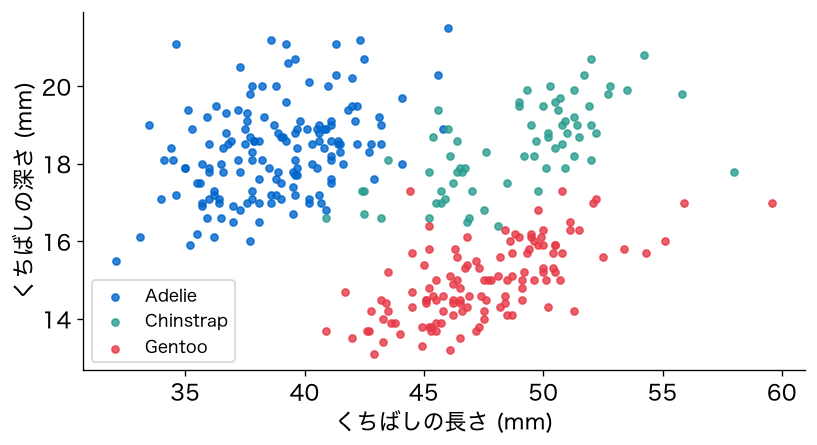

- 横がくちばしの長さ、縦が深さ

## Adelieは、左に固まる

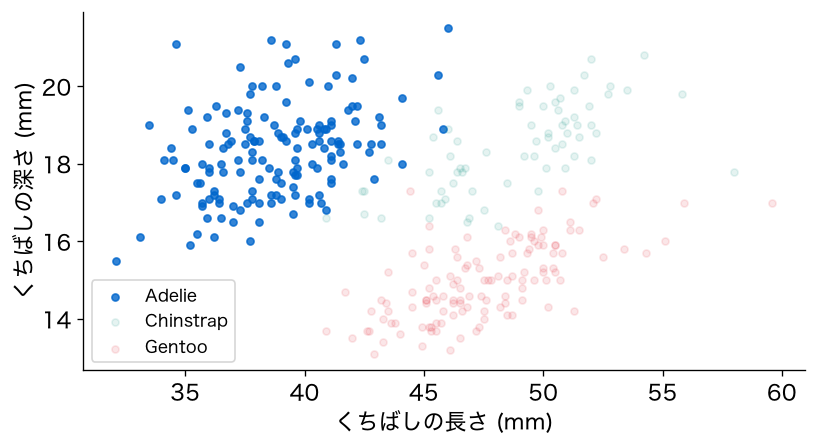

- くちばしが短い側。係数の −4.43と同じ話

## Gentooは、下に固まる

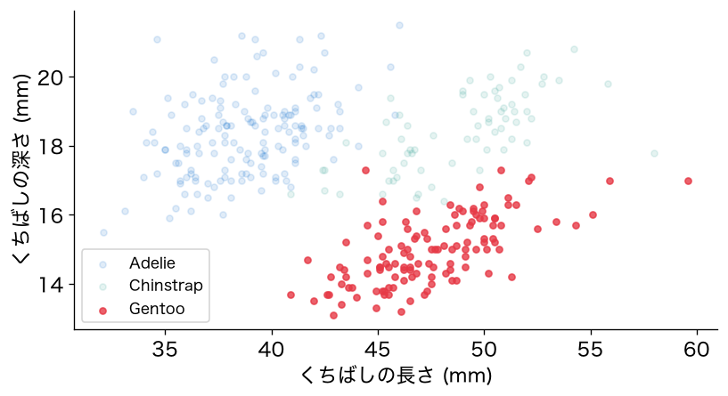

- くちばしが浅い側。係数の −2.15と同じ話

## Chinstrapは、右上に固まる

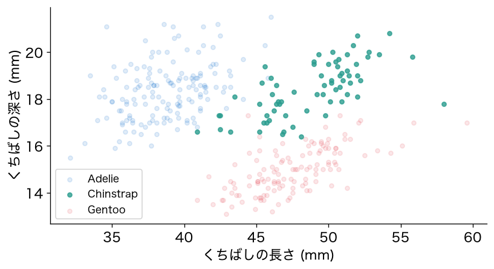

- くちばしが長くて深い側

## 2本だけで、かなり分かれる

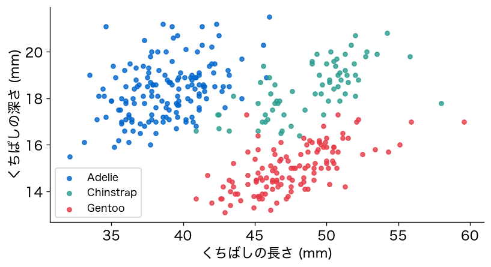

- くちばしの長さと深さの2本で、3種がかなりきれいに分かれる

# 6. 答えを出す

## 材料はそろった。何と報告する？

- 4節で、見分ける力を確かめた
- 5節で、モデルが使った測定を確かめた

## 調査担当者の答え

4つの測定と島・性別から、3種を見分けられる。テストでは69羽のうち68羽（0.986）を当てた。このモデルが主に使ったのは、Adelieではくちばしの長さ、Gentooではくちばしの深さ。

## 係数の順位の、注意

- 係数の順位は、「このモデルが主に使った列」
- 似た動きの列どうし（翼の長さと体重など）は、係数を分け合う

## 役立つ順とは、限らない

- だから、測定そのものが見分けに役立つ順とは限らない

## まだ言えないこと①：欠けた測定

- モデルが主に使ったくちばしの長さがなくても、見分けられるか（課題）

## まだ言えないこと②：新しい1羽

- 学んだモデルを保存して、あとで新しい1羽を判定できるか（発展）

# 7. 1本のスクリプトに

## コードが、散らばっている

- ここまでのコードは、ノートのあちこちにある
- 別の条件でやり直すとき、どのセルをどの順で実行すればよいか迷う

## 4つの関数に分ける

- `load`：読み込んで、分ける
- `build_pipeline`：前処理＋モデルを組む

## 測ることと、テストを分ける

- `evaluate`：訓練の中で交差検証
- `final_test`：選び終えたあと、最後に一度だけテスト

## おさらい：def

```python
def 名前(引数):
    return 戻り値
```

- `def`の後ろが名前と引数（入力）、`return`の後ろが戻り値（出力）（第3回）

## お手本：load

```python
def load(path):                               # 読み込んで、分ける
    df = pd.read_csv(path)
    X, y = df.drop(columns='species'), df['species']
    return train_test_split(X, y, test_size=0.2,
                            random_state=42, stratify=y)
```

- ファイルの場所を受け取り、訓練とテストの4つを返す

## お手本：build_pipeline

```python
def build_pipeline(num_cols, cat_cols, C=1.0):   # 前処理＋モデル
    num_steps = Pipeline([('imp', SimpleImputer(strategy='median')),
                          ('sc', StandardScaler())])
    cat_steps = Pipeline([
        ('imp', SimpleImputer(strategy='most_frequent')),
        ('oh', OneHotEncoder(handle_unknown='ignore'))])
    pre = ColumnTransformer([('num', num_steps, num_cols),
                             ('cat', cat_steps, cat_cols)])
    model = LogisticRegression(C=C, max_iter=5000)
    return Pipeline([('pre', pre), ('model', model)])
```

## 列とCを、引数で受け取る

```python
def build_pipeline(num_cols, cat_cols, C=1.0):   # 前処理＋モデル
```

- 2節と3節の中身を、1つの関数に入れた
- 列の並びとCを変えれば、別のパイプラインができる

## お手本：evaluateとfinal_test

```python
def evaluate(model, X_tr, y_tr):                 # 訓練の中で交差検証
    return cross_val_score(model, X_tr, y_tr, cv=5).mean()

def final_test(model, X_tr, y_tr, X_te, y_te):   # 一度だけテスト
    model.fit(X_tr, y_tr)
    return model.score(X_te, y_te)
```

## 比べるのは、evaluateの値だけ

- `evaluate`は、テストを見ない。何度呼んで比べてもよい
- `final_test`は、選び終えたあとに一度だけ呼ぶ

## お手本：呼ぶのは3行

```python
X_tr, X_te, y_tr, y_te = load(f'{DATA_DIR}/penguins.csv')
model = build_pipeline(num, cat, C=10)
print('交差検証', round(evaluate(model, X_tr, y_tr), 3))
```

- この3行だけで、どの順で何をしたかがわかる

## 定義と、呼び出し

- 上の関数の定義を読めば、どんな部品があるかがわかる
- 下の3行を読めば、どの順で何をしたかがわかる

## 変えてみる：Cを変えて、比べる

```python
weak = build_pipeline(num, cat, C=0.01)
print('交差検証', round(evaluate(weak, X_tr, y_tr), 3))
```

- やり直しは、呼ぶ行を変えるだけ。比べるのは交差検証で

## お手本：最後に一度だけ、テスト

```python
print('テスト', round(final_test(model, X_tr, y_tr, X_te, y_te), 3))
```

- 選んだC＝10の`model`を、訓練全体で学び、テストで確かめる

## やってみよう：7節

- 7節のお手本と「変えてみる」のセルを実行する
- 3節・4節と同じ数が出るか？Cを変えると、交差検証はどうなるか？

動画の人は、ここで一時停止。

## 答え合わせ：同じ数が、3行で

```
交差検証 0.996
```

- 交差検証0.996。3節と同じ

## 関数の中の名前は、中だけ

- `load`の中の`df`は、関数の中だけの名前
- 外の`df`を書きかえることはない

## 答え合わせ：C＝0.01

```
交差検証 0.924
```

- 交差検証が下がった。縮めすぎ

## 3節の選択と、合っている

- 3節のGridSearchCVは、0.01を選ばなかった
- 関数で試しても、交差検証で同じことが確かめられた

## 答え合わせ：最後のテスト

```
テスト 0.986
```

- 選んだC＝10で、一度だけ。4節と同じ0.986

## 部品と手順を、分けて書く

- 条件を変えたやり直しが楽になる
- 読む人にも、流れが見える

# まとめ

## 今日の歩み

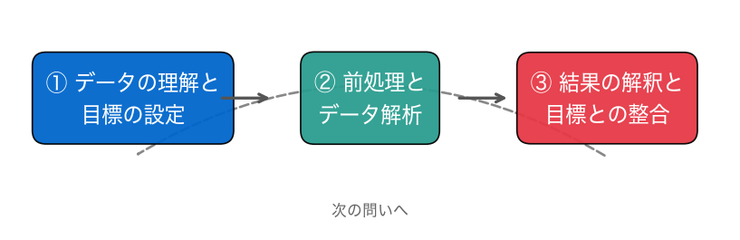

理解 → 前処理の設計 → 交差検証 → テスト → 係数と散布図 → 報告 → 1本のスクリプト

## 今日の要点

- 前処理は、1節で見たこと（欠け・単位・区分）から設計する
- 3種の分類でも、ロジスティック回帰は種ごとに係数を持つ
- 係数の符号と大きさを、平均や散布図と照らし合わせる（大きさは測定値どうしで比べる）
- テストは、最後に一度だけ。比べるのは交差検証で
- Python：手順を関数に分け、定義と呼び出しを分けて1本にまとめる

## 課題の出し方

- ノートの最後の「課題（提出）」に取り組む
- 応用②の答えと応用③の文章を、LACSに入力して提出（＝出席。期限なし）
- AIを使ってもよい。何を聞いて、どう直したかを1行書く

## 次回予告①：ラベルのないデータへ

- ここまでは、いつも正解のラベルがあった
- 次回は、ラベルのないデータで、たくさんの列を少ない本数に縮める

## 次回予告②：次回の問い

400枚の顔を、見分ける力を落とさずに持つには、1枚あたり何個の数でよいか？

## このあと：課題へ

ノートの「課題（提出）」へ。くちばしの長さを測れなかったら、3種を見分けられるか。